# Baloto

Andres Rodriguez

2023-06-25

# Extraccion de datos

Los datos fueron obtenidos de la pagina oficial de Baloto “https://www.balotoresultados.co/historico” a partir del año 2017

El dataset compuesto de :

| **Variable** | **Tipo** | **Descripción** |
| --- | --- | --- |
| Fecha | Date | Fecha del sorteo |
| Balota_1 | Int | Resultado de la balota 1 |
| Balota_2 | Int | Resultado de la balota 2 |
| Balota_3 | Int | Resultado de la balota 3 |
| Balota_4 | Int | Resultado de la balota 4 |
| Balota_5 | Int | Resultado de la balota 5 |
| Super_balota | Int | Resultado de la superbalota |

Se cargan los datos y ajustan formatos de variables

```r
baloto <- read.csv("Data/baloto.csv")
names(baloto) <- c("Fecha", "Balota_1", "Balota_2", "Balota_3", "Balota_4", "Balota_5", "Super_balota")
baloto$Fecha <- as.Date(baloto$Fecha, format = '%m/%d/%Y')
baloto$anio = year(baloto$Fecha)
# Se muestran los primeros 5 registros del dataset
head(baloto)
```

| Fecha | Balota_1 | Balota_2 | Balota_3 | Balota_4 | Balota_5 | Super_balota | anio |
| --- | --- | --- | --- | --- | --- | --- | --- |
| 2017-04-22 | 15 | 28 | 36 | 37 | 41 | 10 | 2017 |
| 2017-04-26 | 1 | 2 | 25 | 31 | 33 | 14 | 2017 |
| 2017-04-29 | 6 | 19 | 25 | 28 | 36 | 1 | 2017 |
| 2017-05-03 | 5 | 6 | 7 | 12 | 37 | 6 | 2017 |
| 2017-05-06 | 1 | 20 | 36 | 39 | 43 | 10 | 2017 |
| 2017-05-10 | 12 | 19 | 22 | 35 | 38 | 1 | 2017 |

```r
# Se comprueba formato de las variables
str(baloto)
```

```
## 'data.frame':    603 obs. of  8 variables:
##  $ Fecha       : Date, format: "2017-04-22" "2017-04-26" ...
##  $ Balota_1    : int  15 1 6 5 1 12 11 15 1 7 ...
##  $ Balota_2    : int  28 2 19 6 20 19 19 21 11 22 ...
##  $ Balota_3    : int  36 25 25 7 36 22 27 26 28 29 ...
##  $ Balota_4    : int  37 31 28 12 39 35 28 28 31 32 ...
##  $ Balota_5    : int  41 33 36 37 43 38 37 36 41 41 ...
##  $ Super_balota: int  10 14 1 6 10 1 8 3 9 14 ...
##  $ anio        : num  2017 2017 2017 2017 2017 ...
```

# Analisis descriptivo

Se revisan estadísticos básicos y aqui algunas particuladirades que cuando menos resultan interesantes:

- Parece que la balota Nº 4 no ha sacado valor `1` por lo menos desde la muestra de los datos.

Siendo un juego de azar quizá se podría esperar una distribución de frecuencias uniforme, sin embargo:

1. La balota Nº 1 concentra el 75% de sus resultados con valores <= 13
2. Lo contrario sucede con la balota Nº 5 en la que sus resultados (50%) están concentrados en 13% de sus valores.
3. El resto de balotas parecen tener un comportamiento un poco mas “uniforme” aunque igualmente se pueden denotar algunas tendencias.

|  | Fecha | Balota_1 | Balota_2 | Balota_3 | Balota_4 | Balota_5 | Super_balota | anio |
| --- | --- | --- | --- | --- | --- | --- | --- | --- |
|  | Min. :2017-04-22 | Min. : 1.00 | Min. : 1.00 | Min. : 1.00 | Min. : 2.00 | Min. : 1.0 | Min. : 1.000 | Min. :2017 |
|  | 1st Qu.:2018-10-01 | 1st Qu.: 3.00 | 1st Qu.: 9.00 | 1st Qu.:15.00 | 1st Qu.:23.00 | 1st Qu.:31.0 | 1st Qu.: 4.000 | 1st Qu.:2018 |
|  | Median :2020-03-11 | Median : 7.00 | Median :15.00 | Median :22.00 | Median :30.00 | Median :37.0 | Median : 9.000 | Median :2020 |
|  | Mean :2020-03-28 | Mean : 9.34 | Mean :16.13 | Mean :22.18 | Mean :27.92 | Mean :34.3 | Mean : 8.476 | Mean :2020 |
|  | 3rd Qu.:2021-09-23 | 3rd Qu.:13.00 | 3rd Qu.:21.00 | 3rd Qu.:28.00 | 3rd Qu.:35.00 | 3rd Qu.:41.0 | 3rd Qu.:12.000 | 3rd Qu.:2021 |
|  | Max. :2023-03-08 | Max. :43.00 | Max. :43.00 | Max. :43.00 | Max. :43.00 | Max. :43.0 | Max. :16.000 | Max. :2023 |

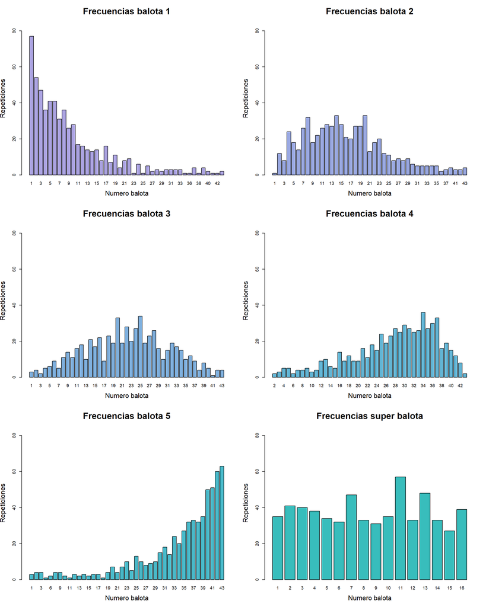

Valor medio resultado de cada balota con el rango de desviación muestral:

| **Variable** | **Balota Media** | **$\pm$ Balotas** |
| --- | --- | --- |
| Balota_1 | 9 | 9 |
| Balota_2 | 16 | 9 |
| Balota_3 | 22 | 9 |
| Balota_4 | 28 | 9 |
| Balota_5 | 34 | 9 |
| Super_balota | 8 | 5 |